# Yahoo Finance Examples

Prof. Gareth W. Peters

2023-01-08

# Yahoo Finance - useful source of Data

www.finance.yahoo.com

- Go to the search menu and look up your favourite stock ticker

Where do I find out the stock ticker symbol?

Many places to look, for instance:

- https://stockanalysis.com/stocks/
- https://www.tradingview.com/screener/

# Yahoo Finance - useful source of Data

Lets take Apple AAPL

- Go to search
- enter AAPL hit return
- Get to Summary page
- select menu Chart
- https://yhoo.it/3Qmrkax

# Yahoo Finance - useful source of Data

You can also get data for this asset by going to menu historical data:

- https://finance.yahoo.com/quote/AAPL/history?p=AAPL

Then you can download this data to a csv file.

# Package Install and Call Libraries for R to use

With the csv file you can read it into R

- But first you need to set up packages (install & call)

Comment: Keep all your libraries etc in one convenient place

- install them first

Examples of packages I often use and so install

Consider to install Rtools.

https://cran.r-project.org/bin/windows/Rtools/rtools43/rtools.html

- install.packages(‘tidyverse’)
- install.packages(‘readr’)
- install.packages(‘knitr’)
- install.packages(‘zoo’)
- install.packages(‘dplyr’)
- install.packages(‘lubridate’)
- install.packages(‘Rtools’)
- install.packages(‘fpp2’, dependencies = TRUE)
- install.packages(“tsibble”)

or

- remotes::install_github(“tidyverts/tsibble”)

OR install the development version from github repo

- install.packages(“remotes”)
- remotes::install_github(“robjhyndman/fpp2-package”)

https://cran.r-project.org/web/packages/seasonal/seasonal.pdf

- install.packages(“seasonal”)
- install.packages(“seasonal”, type = “source”)
- install.packages(“seasonalview”)
- install.packages(‘xts’)

Comment on Library vs Require

The library() by default returns an error if the requested package does not exist.

example:

library(xyz)

Error in library(xyz) : there is no package called ‘xyz’

The require() is designed to be used inside functions as it gives a warning message and returns a logical value say, FALSE if the requested package is not found and TRUE if the package is loaded.

example:

require(xyz)

Loading required package: xyz

Warning message:

In library(package, lib.loc = lib.loc, character.only = TRUE, logical.return = TRUE,) :

there is no package called ‘xyz’

It is better to use the library() as it gives the error message if the package is not found during the package loading time.

This will indeed avoid unnecessary headaches of tracking down the errors caused while attempting to use the library routines which are not installed.

So now we can set up our libraries for R using commands

- library(tidyverse)
- library(tidyverse)
- library(Rtools)
- library(tidyverse)
- library(readr)
- library(knitr)
- library(zoo)
- library(dplyr)
- library(lubridate)
- library(fpp2)
- library(tsibble)
- library(seasonal)
- library(seasonalview)
- library(xts)

# Setup the working directory

Method 1: using files tab in RStudio

- set working directory manually via navigating to directory
- select cog icon menu and select set as working directory

Method 2: do in code / command line directly

Get and print current working directory.

- print(getwd())

paste the command output into your setwd function as below

- setwd(“C:/Users/Gareth W. Peters/Documents/R/PSTAT174_274”)

or using syntax with a double forward slash \ \

- setwd(“C:\ \Users\ \Gareth W. Peters\ \Documents\ \R\ \PSTAT174_274”)

Get and print current working directory.

- print(getwd())

what files are in this directory?

- list.files()

# Read and Plot Data from CSV

The tidyverse environment is what is recommened for best coding practice in modern R environments.

- tidyverse uses tibble structures (see notes)

tidyverse has a time series tibble structure:

https://tsibble.tidyverts.org/

https://cran.r-project.org/web/packages/tsibble/index.html

- Reading in csv (comma separated data) in R using readr package

```r
AAPL_Daily <- readr::read_csv("AAPL.csv",show_col_types = FALSE)

print(AAPL_Daily)
```

```
## # A tibble: 250 × 7
##    Date        Open  High   Low Close `Adj Close`    Volume
##    <date>     <dbl> <dbl> <dbl> <dbl>       <dbl>     <dbl>
##  1 2022-01-10  169.  172.  168.  172.        171. 106765600
##  2 2022-01-11  172.  175.  171.  175.        174.  76138300
##  3 2022-01-12  176.  177.  175.  176.        175.  74805200
##  4 2022-01-13  176.  177.  172.  172.        171.  84505800
##  5 2022-01-14  171.  174.  171.  173.        172.  80440800
##  6 2022-01-18  172.  173.  169.  170.        169.  90956700
##  7 2022-01-19  170   171.  166.  166.        165.  94815000
##  8 2022-01-20  167.  170.  164.  165.        164.  91420500
##  9 2022-01-21  164.  166.  162.  162.        161. 122848900
## 10 2022-01-24  160.  162.  155.  162.        161. 162294600
## # … with 240 more rows
```

```r
# or

AAPL_Daily2 <- read.csv("AAPL.csv")

print(AAPL_Daily2)
```

```
##           Date   Open   High    Low  Close Adj.Close    Volume
## 1   2022-01-10 169.08 172.50 168.17 172.19  171.1964 106765600
## 2   2022-01-11 172.32 175.18 170.82 175.08  174.0697  76138300
## 3   2022-01-12 176.12 177.18 174.82 175.53  174.5171  74805200
## 4   2022-01-13 175.78 176.62 171.79 172.19  171.1964  84505800
## 5   2022-01-14 171.34 173.78 171.09 173.07  172.0713  80440800
## 6   2022-01-18 171.51 172.54 169.41 169.80  168.8202  90956700
## 7   2022-01-19 170.00 171.08 165.94 166.23  165.2708  94815000
## 8   2022-01-20 166.98 169.68 164.18 164.51  163.5607  91420500
## 9   2022-01-21 164.42 166.33 162.30 162.41  161.4728 122848900
## 10  2022-01-24 160.02 162.30 154.70 161.62  160.6874 162294600
## 11  2022-01-25 158.98 162.76 157.02 159.78  158.8580 115798400
## 12  2022-01-26 163.50 164.39 157.82 159.69  158.7685 108275300
## 13  2022-01-27 162.45 163.84 158.28 159.22  158.3012 121954600
## 14  2022-01-28 165.71 170.35 162.80 170.33  169.3472 179935700
```

[output cut: 236 more lines]

Are they the same type?

```r
class(AAPL_Daily)
```

```
## [1] "spec_tbl_df" "tbl_df"      "tbl"         "data.frame"
```

```r
class(AAPL_Daily2)
```

```
## [1] "data.frame"
```

What does the data structure contain?

- summary() or head() can help

summarise the data first few lines

```r
head(AAPL_Daily)
```

```
## # A tibble: 6 × 7
##   Date        Open  High   Low Close `Adj Close`    Volume
##   <date>     <dbl> <dbl> <dbl> <dbl>       <dbl>     <dbl>
## 1 2022-01-10  169.  172.  168.  172.        171. 106765600
## 2 2022-01-11  172.  175.  171.  175.        174.  76138300
## 3 2022-01-12  176.  177.  175.  176.        175.  74805200
## 4 2022-01-13  176.  177.  172.  172.        171.  84505800
## 5 2022-01-14  171.  174.  171.  173.        172.  80440800
## 6 2022-01-18  172.  173.  169.  170.        169.  90956700
```

```r
summary(AAPL_Daily)
```

```
##       Date                 Open            High            Low
##  Min.   :2022-01-10   Min.   :126.0   Min.   :127.8   Min.   :124.2
##  1st Qu.:2022-04-08   1st Qu.:143.5   1st Qu.:146.6   1st Qu.:141.1
##  Median :2022-07-11   Median :152.7   Median :155.3   Median :150.9
##  Mean   :2022-07-09   Mean   :153.9   Mean   :156.0   Mean   :151.8
##  3rd Qu.:2022-10-06   3rd Qu.:165.0   3rd Qu.:167.1   3rd Qu.:163.0
##  Max.   :2023-01-06   Max.   :178.6   Max.   :179.6   Max.   :176.7
##      Close         Adj Close         Volume
##  Min.   :125.0   Min.   :125.0   Min.   : 35195900
##  1st Qu.:143.8   1st Qu.:143.4   1st Qu.: 72272050
##  Median :153.0   Median :152.5   Median : 83424500
##  Mean   :154.0   Mean   :153.5   Mean   : 87813449
##  3rd Qu.:165.2   3rd Qu.:164.6   3rd Qu.: 96325700
##  Max.   :179.0   Max.   :178.2   Max.   :182602000
```

What if there is more than one field - how to access one

We can also see one field if we label each column with a header.

```r
AAPL_Daily$Date
```

```
##   [1] "2022-01-10" "2022-01-11" "2022-01-12" "2022-01-13" "2022-01-14"
##   [6] "2022-01-18" "2022-01-19" "2022-01-20" "2022-01-21" "2022-01-24"
##  [11] "2022-01-25" "2022-01-26" "2022-01-27" "2022-01-28" "2022-01-31"
##  [16] "2022-02-01" "2022-02-02" "2022-02-03" "2022-02-04" "2022-02-07"
##  [21] "2022-02-08" "2022-02-09" "2022-02-10" "2022-02-11" "2022-02-14"
##  [26] "2022-02-15" "2022-02-16" "2022-02-17" "2022-02-18" "2022-02-22"
##  [31] "2022-02-23" "2022-02-24" "2022-02-25" "2022-02-28" "2022-03-01"
##  [36] "2022-03-02" "2022-03-03" "2022-03-04" "2022-03-07" "2022-03-08"
##  [41] "2022-03-09" "2022-03-10" "2022-03-11" "2022-03-14" "2022-03-15"
##  [46] "2022-03-16" "2022-03-17" "2022-03-18" "2022-03-21" "2022-03-22"
##  [51] "2022-03-23" "2022-03-24" "2022-03-25" "2022-03-28" "2022-03-29"
##  [56] "2022-03-30" "2022-03-31" "2022-04-01" "2022-04-04" "2022-04-05"
##  [61] "2022-04-06" "2022-04-07" "2022-04-08" "2022-04-11" "2022-04-12"
##  [66] "2022-04-13" "2022-04-14" "2022-04-18" "2022-04-19" "2022-04-20"
##  [71] "2022-04-21" "2022-04-22" "2022-04-25" "2022-04-26" "2022-04-27"
```

[output cut: 35 more lines]

```r
AAPL_Daily$Open
```

```
##   [1] 169.08 172.32 176.12 175.78 171.34 171.51 170.00 166.98 164.42 160.02
##  [11] 158.98 163.50 162.45 165.71 170.16 174.01 174.75 174.48 171.68 172.86
##  [21] 171.73 176.05 174.14 172.33 167.37 170.97 171.85 171.03 169.82 164.98
##  [31] 165.54 152.58 163.84 163.06 164.70 164.39 168.47 164.49 163.36 158.82
##  [41] 161.48 160.20 158.93 151.45 150.90 157.05 158.61 160.51 163.51 165.51
##  [51] 167.99 171.06 173.88 172.17 176.69 178.55 177.84 174.03 174.57 177.50
##  [61] 172.36 171.16 171.78 168.71 168.02 167.39 170.62 163.92 165.02 168.76
##  [71] 168.91 166.46 161.12 162.25 155.91 159.25 161.84 156.71 158.15 159.67
##  [81] 163.85 156.01 154.93 155.52 153.50 142.77 144.59 145.55 148.86 146.85
##  [91] 139.88 139.09 137.79 140.81 138.43 137.39 145.39 149.07 149.90 147.83
## [101] 146.90 147.03 144.35 148.58 147.08 140.28 132.87 133.13 134.29 132.08
## [111] 130.07 133.42 134.79 136.82 139.90 142.70 142.13 137.46 137.25 136.04
## [121] 137.77 141.35 143.29 145.26 145.67 145.76 142.99 144.08 149.78 150.74
## [131] 147.92 151.12 154.50 155.39 154.01 152.26 152.58 156.98 161.24 161.01
## [141] 160.10 160.84 166.01 163.21 166.37 164.02 167.68 170.06 169.82 171.52
## [151] 172.78 172.77 173.75 173.03 169.69 167.08 167.32 168.78 170.57 161.15
## [161] 162.13 160.31 156.64 159.75 156.47 154.82 154.64 155.47 159.59 159.90
## [171] 154.79 154.65 151.21 149.31 153.40 157.34 152.38 151.19 149.66 152.74
## [181] 147.64 146.10 141.28 138.21 145.03 144.07 145.81 142.54 140.42 139.90
## [191] 139.13 134.99 144.31 141.07 145.49 141.69 143.02 142.87 147.19 150.09
## [201] 150.96 148.07 148.20 153.16 155.08 148.95 142.06 142.09 137.11 140.41
## [211] 138.50 141.24 145.82 148.97 152.22 149.13 146.43 152.31 150.16 148.13
## [221] 149.45 148.31 145.14 144.29 141.40 148.21 145.96 147.77 147.07 142.19
## [231] 142.36 142.34 142.70 149.50 145.35 141.11 136.69 135.11 131.39 132.98
## [241] 134.35 130.92 131.38 129.67 127.99 128.41 130.28 126.89 127.13 126.01
```

Can make a certain date format in Date String

- note here this data already has a nice date format so this call wont do much

```r
AAPL_Daily$Date <- as.Date(AAPL_Daily$Date)
```

Lets check if it worked by printing say the first 10 rows fo the table.

```r
AAPL_Daily$Date[1:10]
```

```
##  [1] "2022-01-10" "2022-01-11" "2022-01-12" "2022-01-13" "2022-01-14"
##  [6] "2022-01-18" "2022-01-19" "2022-01-20" "2022-01-21" "2022-01-24"
```

I only want to keep the first date column and the open values

- it was presented as OHLC - Open, High, Low, Close etc

now lets export the data for the first two columns of the data

- Column 1 - date converted times
- Column 2 - open value

```r
write.csv(data.frame(AAPL_Daily$Date,AAPL_Daily$Open), "AAPL_Daily_Open.csv", row.names=FALSE)
```

How can I turn the data into a format tibble?

Lets now create the tibble with this data:

```r
AAPL_Daily_Open <- readr::read_csv("AAPL_Daily_Open.csv")
# Lets check the structure

AAPL_Daily_Open[1,]
```

```
## # A tibble: 1 × 2
##   AAPL_Daily.Date AAPL_Daily.Open
##   <date>                    <dbl>
## 1 2022-01-10                 169.
```

```r
AAPL_Daily_Open[1,1]
```

```
## # A tibble: 1 × 1
##   AAPL_Daily.Date
##   <date>
## 1 2022-01-10
```

```r
AAPL_Daily_Open[1,2]
```

```
## # A tibble: 1 × 1
##   AAPL_Daily.Open
##             <dbl>
## 1            169.
```

Lets see if can also turn this data into a ts object?

```r
AAPL_Daily_Open_ts <- ts(AAPL_Daily_Open$AAPL_Daily.Open, start = c(2022,1), frequency = 365)
```

Lets see if this worked

```r
AAPL_Daily_Open_ts
```

```
## Time Series:
## Start = c(2022, 1)
## End = c(2022, 250)
## Frequency = 365
##   [1] 169.08 172.32 176.12 175.78 171.34 171.51 170.00 166.98 164.42 160.02
##  [11] 158.98 163.50 162.45 165.71 170.16 174.01 174.75 174.48 171.68 172.86
##  [21] 171.73 176.05 174.14 172.33 167.37 170.97 171.85 171.03 169.82 164.98
##  [31] 165.54 152.58 163.84 163.06 164.70 164.39 168.47 164.49 163.36 158.82
##  [41] 161.48 160.20 158.93 151.45 150.90 157.05 158.61 160.51 163.51 165.51
##  [51] 167.99 171.06 173.88 172.17 176.69 178.55 177.84 174.03 174.57 177.50
##  [61] 172.36 171.16 171.78 168.71 168.02 167.39 170.62 163.92 165.02 168.76
##  [71] 168.91 166.46 161.12 162.25 155.91 159.25 161.84 156.71 158.15 159.67
##  [81] 163.85 156.01 154.93 155.52 153.50 142.77 144.59 145.55 148.86 146.85
##  [91] 139.88 139.09 137.79 140.81 138.43 137.39 145.39 149.07 149.90 147.83
## [101] 146.90 147.03 144.35 148.58 147.08 140.28 132.87 133.13 134.29 132.08
## [111] 130.07 133.42 134.79 136.82 139.90 142.70 142.13 137.46 137.25 136.04
## [121] 137.77 141.35 143.29 145.26 145.67 145.76 142.99 144.08 149.78 150.74
## [131] 147.92 151.12 154.50 155.39 154.01 152.26 152.58 156.98 161.24 161.01
## [141] 160.10 160.84 166.01 163.21 166.37 164.02 167.68 170.06 169.82 171.52
## [151] 172.78 172.77 173.75 173.03 169.69 167.08 167.32 168.78 170.57 161.15
## [161] 162.13 160.31 156.64 159.75 156.47 154.82 154.64 155.47 159.59 159.90
## [171] 154.79 154.65 151.21 149.31 153.40 157.34 152.38 151.19 149.66 152.74
## [181] 147.64 146.10 141.28 138.21 145.03 144.07 145.81 142.54 140.42 139.90
## [191] 139.13 134.99 144.31 141.07 145.49 141.69 143.02 142.87 147.19 150.09
## [201] 150.96 148.07 148.20 153.16 155.08 148.95 142.06 142.09 137.11 140.41
## [211] 138.50 141.24 145.82 148.97 152.22 149.13 146.43 152.31 150.16 148.13
## [221] 149.45 148.31 145.14 144.29 141.40 148.21 145.96 147.77 147.07 142.19
## [231] 142.36 142.34 142.70 149.50 145.35 141.11 136.69 135.11 131.39 132.98
## [241] 134.35 130.92 131.38 129.67 127.99 128.41 130.28 126.89 127.13 126.01
```

Always helps to start with simple data visualisation

Now lets plot the data

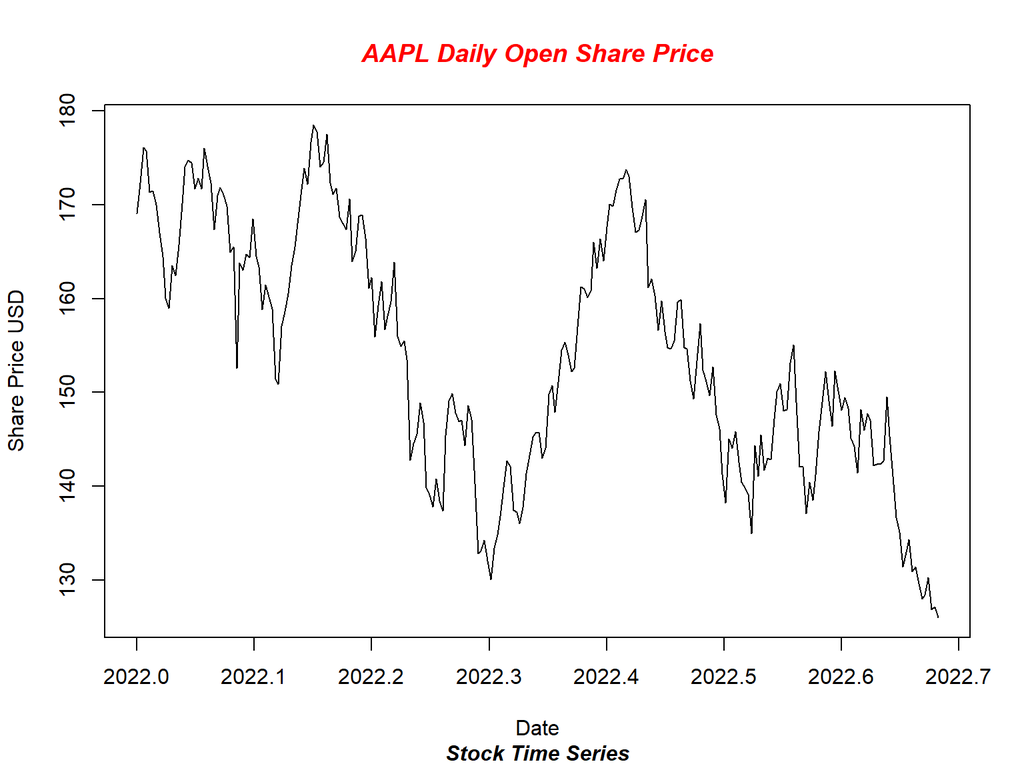

```r
plot(AAPL_Daily_Open_ts, main="AAPL Daily Open Share Price", xlab="Date", ylab="Share Price USD", sub="Stock Time Series", col.main='red', col.lab='blue', col.sub='black',font.main=4, font.lab=4, font.sub=4)
```

Note that, the R par() function can be used to change the color, font style and size for the graph titles. The modifications done by the par() function are called ‘permanent modification’ because they are applied to all the plots generated under the current R session.

Read more on par() by clicking here.

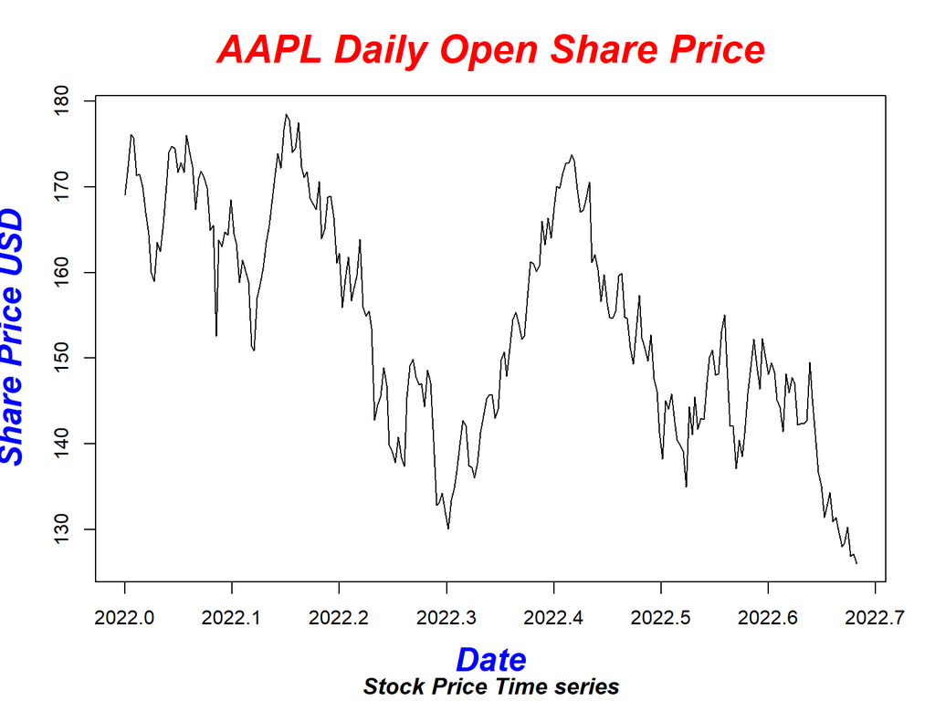

```r
par(
  # Change the colors
  col.main="red", col.lab="blue", col.sub="black",
  # Titles in italic and bold
  font.main=4, font.lab=4, font.sub=4,
  # Change font size
  cex.main=2, cex.lab=1.7, cex.sub=1.2
  )

plot(AAPL_Daily_Open_ts, main="AAPL Daily Open Share Price",
        xlab="Date",
        ylab="Share Price USD",
        sub="Stock Price Time series")
```